# Module 6

# Task 3- Exploratory Data Project

## 19 February 2023

## Task 1- Imports

```python
# Import Libraries

import pandas as pd
import numpy as np
import matplotlib.pyplot as plt
import statistics as stats
import imageio.v3 as iio
```

## Task 2-Load Data

```python
# Load data.csv

df = pd.read_csv('Activity_Dataset_V1.csv', index_col=0)
```

This Dataset came from Kaggle. It contains fitness information from a FitBit recording different workouts and more. The information was retrieved from, https://www.kaggle.com/datasets/tanisha1416/my-redmi-fuel-band-record-tracker-fitbit-dataset.

## Task 3-View Data

```python
# View top 10 Lines

df.head(10)
```

|  | activity_day | workout_type | distance | time | calories | total_steps | avg_speed | avg_cadence | max_cadence | avg_pace | max_pace | min_pace | avg_heart_rate | max_heart_rate | min_heart_rate | vo2_max(%) | aerobic(%) | anaerobic(%) | intensive(%) | light(%) |
| --- | --- | --- | --- | --- | --- | --- | --- | --- | --- | --- | --- | --- | --- | --- | --- | --- | --- | --- | --- | --- |
| 0 | 2022-01-01 | Freestyle | 9.30 | 77 | 123 | NaN | 18.88 | 168.54 | 138.30 | NaN | NaN | NaN | 112.5 | 122.0 | 103 | 19 | 28 | 2 | 7 | 50 |
| 1 | 2022-01-01 | Freestyle | 3.44 | 96 | 55 | NaN | 29.65 | 125.92 | 292.81 | NaN | NaN | NaN | 111.0 | 122.0 | 100 | 42 | 28 | 2 | 29 | 88 |
| 2 | 2022-01-01 | Indoor Cycling | 6.34 | 85 | 33 | NaN | 17.85 | 81.93 | 323.69 | NaN | NaN | NaN | 95.0 | 90.0 | 100 | 1 | 32 | 0 | 22 | 43 |
| 3 | 2022-01-01 | Walking | 7.91 | 42 | 82 | 1571.0 | 22.10 | 29.63 | 180.16 | 07:58 | 28:58 | 07:58 | 83.0 | 85.0 | 81 | 3 | 22 | 0 | 24 | 65 |
| 4 | 2022-01-01 | Open Water | 8.99 | 36 | 131 | NaN | 25.83 | 64.55 | 342.89 | NaN | NaN | NaN | 138.0 | 166.0 | 110 | 7 | 0 | 5 | 21 | 88 |
| 5 | 2022-01-01 | Outdoor Cycling | 5.47 | 117 | 144 | NaN | 2.20 | 43.47 | 291.67 | NaN | NaN | NaN | 142.0 | 177.0 | 107 | 44 | 45 | 15 | 57 | 39 |
| 6 | 2022-01-01 | Indoor Cycling | 6.28 | 66 | 378 | NaN | 10.65 | 23.83 | 253.84 | NaN | NaN | NaN | 85.0 | 90.0 | 80 | 34 | 32 | 0 | 44 | 23 |
| 7 | 2022-01-01 | Outdoor Running | 2.94 | 26 | 430 | 7618.0 | 10.59 | 131.93 | 334.72 | 06:44 | 27:44 | 06:15 | 145.0 | 190.0 | 100 | 23 | 0 | 71 | 18 | 3 |
| 8 | 2022-01-01 | Trail Run | 2.87 | 26 | 465 | 2790.0 | 32.92 | 21.42 | 341.17 | 06:48 | 25:50 | 06:20 | 142.0 | 188.0 | 96 | 2 | 0 | 80 | 46 | 13 |
| 9 | 2022-01-01 | Pool Swimming | 3.91 | 23 | 99 | NaN | 33.15 | 169.30 | 206.97 | NaN | NaN | NaN | 132.5 | 175.0 | 90 | 22 | 20 | 15 | 28 | 20 |

```python
# View bottom 10 Lines

df.tail(10)
```

|  | activity_day | workout_type | distance | time | calories | total_steps | avg_speed | avg_cadence | max_cadence | avg_pace | max_pace | min_pace | avg_heart_rate | max_heart_rate | min_heart_rate | vo2_max(%) | aerobic(%) | anaerobic(%) | intensive(%) | light(%) |
| --- | --- | --- | --- | --- | --- | --- | --- | --- | --- | --- | --- | --- | --- | --- | --- | --- | --- | --- | --- | --- |
| 990 | 2022-02-14 | Treadmill | 1.81 | 58 | 76 | 4550.0 | 34.80 | 66.16 | 99.72 | 07:59 | 27:58 | 07:58 | 94.0 | 105.0 | 83 | 8 | 26 | 7 | 7 | 10 |
| 991 | 2022-02-14 | Freestyle | 2.41 | 20 | 527 | NaN | 29.90 | 138.62 | 209.50 | NaN | NaN | NaN | 110.5 | 122.0 | 99 | 4 | 28 | 2 | 44 | 67 |
| 992 | 2022-02-14 | Outdoor Cycling | 2.67 | 37 | 55 | NaN | 14.44 | 159.59 | 250.11 | NaN | NaN | NaN | 132.0 | 177.0 | 87 | 15 | 45 | 15 | 59 | 100 |
| 993 | 2022-02-14 | Indoor Cycling | 9.17 | 24 | 358 | NaN | 10.92 | 133.94 | 112.51 | NaN | NaN | NaN | 92.0 | 90.0 | 94 | 40 | 32 | 0 | 40 | 74 |
| 994 | 2022-02-14 | Walking | 2.17 | 106 | 172 | 1571.0 | 10.42 | 134.17 | 275.62 | 07:58 | 28:58 | 07:58 | 97.5 | 85.0 | 110 | 30 | 22 | 0 | 52 | 57 |
| 995 | 2022-02-14 | Pool Swimming | 6.92 | 101 | 313 | NaN | 28.66 | 173.30 | 234.73 | NaN | NaN | NaN | 133.5 | 175.0 | 92 | 22 | 20 | 15 | 21 | 61 |
| 996 | 2022-02-14 | Freestyle | 9.48 | 61 | 219 | NaN | 9.23 | 114.34 | 109.32 | NaN | NaN | NaN | 103.0 | 122.0 | 84 | 18 | 28 | 2 | 17 | 86 |
| 997 | 2022-02-14 | Freestyle | 3.30 | 40 | 169 | NaN | 7.37 | 133.97 | 122.96 | NaN | NaN | NaN | 114.5 | 122.0 | 107 | 18 | 28 | 2 | 23 | 98 |
| 998 | 2022-02-14 | Indoor Cycling | 4.40 | 47 | 52 | NaN | 10.75 | 147.65 | 116.51 | NaN | NaN | NaN | 96.0 | 90.0 | 102 | 45 | 32 | 0 | 13 | 57 |
| 999 | 2022-02-14 | Indoor Cycling | 1.57 | 116 | 106 | NaN | 25.37 | 143.41 | 182.80 | NaN | NaN | NaN | 96.5 | 90.0 | 103 | 14 | 32 | 0 | 24 | 83 |

```python
# Set precision level

pd.set_option('display.precision', 4)

# Get statistical information using describe function

df.describe()
```

|  | distance | time | calories | total_steps | avg_speed | avg_cadence | max_cadence | avg_heart_rate | max_heart_rate | min_heart_rate | vo2_max(%) | aerobic(%) | anaerobic(%) | intensive(%) | light(%) |
| --- | --- | --- | --- | --- | --- | --- | --- | --- | --- | --- | --- | --- | --- | --- | --- |
| count | 1000.0000 | 1000.0000 | 1000.0000 | 554.0000 | 1000.0000 | 1000.0000 | 1000.0000 | 1000.0000 | 1000.0000 | 1000.0000 | 1000.0000 | 1000.0000 | 1000.0000 | 1000.0000 | 1000.0000 |
| mean | 5.2436 | 71.1660 | 286.3100 | 4081.1191 | 19.7658 | 107.4579 | 199.8219 | 116.2820 | 136.6550 | 95.9090 | 22.3220 | 24.0770 | 17.8990 | 36.2360 | 50.9470 |
| std | 2.6498 | 29.3414 | 156.2785 | 1865.4291 | 10.8710 | 54.3122 | 85.3970 | 20.5737 | 39.7394 | 9.4505 | 12.9412 | 16.8811 | 26.8646 | 18.1253 | 28.2111 |
| min | 1.0000 | 20.0000 | 10.0000 | 1571.0000 | 1.0000 | 10.1300 | 50.5600 | 82.5000 | 85.0000 | 80.0000 | 0.0000 | 0.0000 | 0.0000 | 5.0000 | 2.0000 |
| 25% | 2.8000 | 45.0000 | 155.7500 | 2790.0000 | 10.3000 | 62.5300 | 129.0975 | 97.0000 | 92.0000 | 88.0000 | 11.0000 | 0.0000 | 0.0000 | 21.0000 | 26.0000 |
| 50% | 5.1050 | 71.0000 | 290.5000 | 3444.0000 | 19.3950 | 111.0650 | 198.8000 | 113.0000 | 124.0000 | 96.0000 | 22.0000 | 26.0000 | 7.0000 | 36.0000 | 51.0000 |
| 75% | 7.5425 | 97.0000 | 415.2500 | 5028.0000 | 28.9325 | 153.6050 | 274.2925 | 136.5000 | 177.0000 | 104.0000 | 33.0000 | 40.0000 | 15.0000 | 52.0000 | 76.0000 |
| max | 9.9900 | 120.0000 | 550.0000 | 7618.0000 | 38.9000 | 199.7800 | 349.7800 | 150.5000 | 190.0000 | 111.0000 | 45.0000 | 50.0000 | 80.0000 | 67.0000 | 100.0000 |

```python
# Describe Distance

df.distance.describe()
```

```
count    1000.0000
mean        5.2436
std         2.6498
min         1.0000
25%         2.8000
50%         5.1050
75%         7.5425
max         9.9900
Name: distance, dtype: float64
```

```python
# Describe average speed

df.avg_speed.describe()
```

```
count    1000.0000
mean       19.7658
std        10.8710
min         1.0000
25%        10.3000
50%        19.3950
75%        28.9325
max        38.9000
Name: avg_speed, dtype: float64
```

```python
# Data Types

df.dtypes
```

```
activity_day       object
workout_type       object
distance          float64
time                int64
calories            int64
total_steps       float64
avg_speed         float64
avg_cadence       float64
max_cadence       float64
avg_pace           object
max_pace           object
min_pace           object
avg_heart_rate    float64
max_heart_rate    float64
min_heart_rate      int64
vo2_max(%)          int64
aerobic(%)          int64
anaerobic(%)        int64
intensive(%)        int64
light(%)            int64
dtype: object
```

```python
# Unique Workouts

df.workout_type.unique()
```

```
array(['Freestyle', 'Indoor Cycling', 'Walking', 'Open Water',
       'Outdoor Cycling', 'Outdoor Running', 'Trail Run', 'Pool Swimming',
       'Trekking', 'Treadmill', 'Cricket'], dtype=object)
```

```python
# Get Number of Rows

len(df)
```

```
1000
```

```python
# Number of columns

len(df.columns)
```

```
20
```

## Task 5-Histograms

```python
# Import matplotlib

%matplotlib inline
```

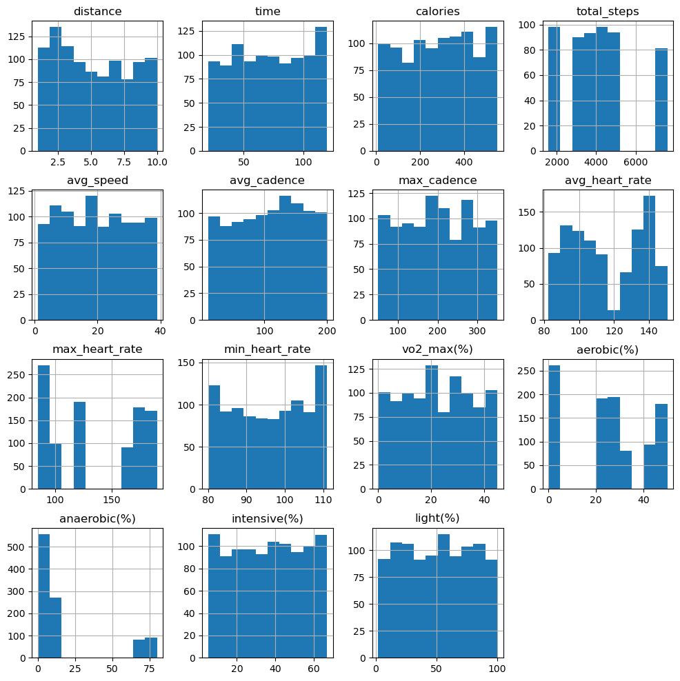

```python
# Histogram for Numerical Content

histograms = df.hist(figsize = (12, 12))
```

## Task 6- Comparing Workout Types

```python
# Import Data For different workout types

freestyle_df = df[df.workout_type == 'Freestyle']
indoor_cycling_df = df[df.workout_type == 'Indoor Cyclinig']
walking_df = df[df.workout_type == 'Walking']
open_water_df = df[df.workout_type == 'Open Water']
outdoor_cycling_df = df[df.workout_type == 'Outdoor Cycling']
outdoor_running_df = df[df.workout_type == 'Outdoor Running']
trail_run_df = df[df.workout_type == 'Trail Run']
pool_swimming_df = df[df.workout_type == 'Pool Swimming']
trekking_df = df[df.workout_type == 'Treadmill']
treadmill_df = df[df.workout_type == 'Trail Run']
cricket_df = df[df.workout_type == 'Cricket']
```

```python
# Compare calorie per workout

def calorie_stats(data):
    min_calories = round(min(data.calories), 4)
    max_calories = round(max(data.calories), 4)
    mean_calories = round(np.mean(data.calories), 4)
    median_calories = round(stats.median(data.calories), 4)
    mode_calories = round(stats.mode(data.calories), 4)
    calories_std = round(np.std(data.calories), 4)
    calories_var = round(np.var(data.calories), 4)
    return f"""Workout Type: {max(data.workout_type)}
Minimum Calories: {min_calories}
Maximum Calories: {max_calories}
Mean Calories: {mean_calories}
Median Calories: {median_calories}
Mode Calories: {mode_calories}
Calorie Standard Deviation: {calories_std}
Calorie Variance: {calories_var}
"""
```

```python
print(calorie_stats(pool_swimming_df))
```

```
Workout Type: Pool Swimming
Minimum Calories: 11
Maximum Calories: 537
Mean Calories: 283.4149
Median Calories: 300.0
Mode Calories: 37
Calorie Standard Deviation: 156.7363
Calorie Variance: 24566.264
```

```python
print(calorie_stats(freestyle_df))
```

```
Workout Type: Freestyle
Minimum Calories: 11
Maximum Calories: 547
Mean Calories: 278.5521
Median Calories: 294.0
Mode Calories: 99
Calorie Standard Deviation: 162.8489
Calorie Variance: 26519.7681
```

```python
print(calorie_stats(walking_df))
```

```
Workout Type: Walking
Minimum Calories: 10
Maximum Calories: 533
Mean Calories: 276.0408
Median Calories: 270.5
Mode Calories: 82
Calorie Standard Deviation: 156.483
Calorie Variance: 24486.9371
```

```python
print(calorie_stats(open_water_df))
```

```
Workout Type: Open Water
Minimum Calories: 17
Maximum Calories: 550
Mean Calories: 296.7473
Median Calories: 328
Mode Calories: 426
Calorie Standard Deviation: 159.1866
Calorie Variance: 25340.3647
```

```python
print(calorie_stats(outdoor_cycling_df))
```

```
Workout Type: Outdoor Cycling
Minimum Calories: 12
Maximum Calories: 545
Mean Calories: 299.1294
Median Calories: 301
Mode Calories: 195
Calorie Standard Deviation: 157.7948
Calorie Variance: 24899.195
```

```python
print(calorie_stats(outdoor_running_df))
```

```
Workout Type: Outdoor Running
Minimum Calories: 13
Maximum Calories: 549
Mean Calories: 301.4691
Median Calories: 349
Mode Calories: 524
Calorie Standard Deviation: 164.6989
Calorie Variance: 27125.7305
```

```python
print(calorie_stats(trail_run_df))
```

```
Workout Type: Trail Run
Minimum Calories: 17
Maximum Calories: 544
Mean Calories: 267.9667
Median Calories: 264.0
Mode Calories: 185
Calorie Standard Deviation: 154.8808
Calorie Variance: 23988.0767
```

```python
print(calorie_stats(trekking_df))
```

```
Workout Type: Treadmill
Minimum Calories: 18
Maximum Calories: 549
Mean Calories: 278.1429
Median Calories: 269.5
Mode Calories: 256
Calorie Standard Deviation: 146.2116
Calorie Variance: 21377.8367
```

```python
print(calorie_stats(treadmill_df))
```

```
Workout Type: Trail Run
Minimum Calories: 17
Maximum Calories: 544
Mean Calories: 267.9667
Median Calories: 264.0
Mode Calories: 185
Calorie Standard Deviation: 154.8808
Calorie Variance: 23988.0767
```

```python
print(calorie_stats(cricket_df))
```

```
Workout Type: Cricket
Minimum Calories: 20
Maximum Calories: 549
Mean Calories: 307.5484
Median Calories: 330
Mode Calories: 467
Calorie Standard Deviation: 149.1422
Calorie Variance: 22243.4089
```

We can see from the data that open water swimming had the highest total calories burnt but cricket had the highest mean of calories burnt. This leads me to infer that the user prefers to play cricket and may be playing it at a higher level or for a longer time. We can calculate this and get a more definitive answer.

```python
def time_stats(data):
    min_time = round(min(data.time), 4)
    max_time = round(max(data.time), 4)
    mean_time = round(np.mean(data.time), 4)
    median_time = round(stats.median(data.time), 4)
    mode_time = round(stats.mode(data.time), 4)
    time_std = round(np.std(data.time), 4)
    time_var = round(np.var(data.time), 4)
    return f"""Workout Type: {max(data.workout_type)}
Minimum time: {min_time}
Maximum time: {max_time}
Mean time: {mean_time}
Median time: {median_time}
Mode time: {mode_time}
Time Standard Deviation: {time_std}
Time Variance: {time_var}
"""
```

```python
print(time_stats(pool_swimming_df))
()
print(time_stats(freestyle_df))
()
print(time_stats(walking_df))
()
print(time_stats(open_water_df))
()
print(time_stats(outdoor_cycling_df))
()
print(time_stats(outdoor_running_df))
()
print(time_stats(trail_run_df))
()
print(time_stats(trekking_df))
()
print(time_stats(treadmill_df))
()
print(time_stats(cricket_df))
```

```
Workout Type: Pool Swimming
Minimum time: 23
Maximum time: 120
Mean time: 75.9787
Median time: 76.5
Mode time: 111
Time Standard Deviation: 28.575
Time Variance: 816.5315

Workout Type: Freestyle
Minimum time: 20
Maximum time: 120
Mean time: 70.8229
Median time: 70.0
Mode time: 108
Time Standard Deviation: 28.8498
Time Variance: 832.3124

Workout Type: Walking
Minimum time: 20
Maximum time: 118
Mean time: 68.6429
Median time: 69.0
Mode time: 69
Time Standard Deviation: 29.2656
Time Variance: 856.4745

Workout Type: Open Water
Minimum time: 20
Maximum time: 120
Mean time: 69.2418
Median time: 69
Mode time: 53
Time Standard Deviation: 29.8532
Time Variance: 891.2163

Workout Type: Outdoor Cycling
Minimum time: 20
Maximum time: 119
Mean time: 73.8824
```

[output cut: 34 more lines]

```
Maximum time: 119
Mean time: 71.7222
Median time: 72.5
Mode time: 78
Time Standard Deviation: 27.3378
Time Variance: 747.3562

Workout Type: Cricket
Minimum time: 23
Maximum time: 120
Mean time: 68.4301
Median time: 67
Mode time: 63
Time Standard Deviation: 26.604
Time Variance: 707.772
```

While the mean calories was highest for Cricket, our hypothesis of more time spent on that activity was wrong. Pool swimming had the highest mean time while cricket was actually the lowest. The assumption here is that cricket was played at a higher intensity now.

```python
# Convert time from minutes to hours/fraction of hours

wo_min = df.time

df['wo_hrs'] = list(map(lambda x: x / 60, wo_min))
```

```python
# String Together

wotypes = list(df.workout_type.unique())

meantime = [round(np.mean(df.time[df.workout_type==wotypes]), 2) for wotypes in wotypes]
for wotypes, meantime in zip(wotypes, meantime):
    print(f"{wotypes} activity took an average of {meantime} hours to complete.")
```

[output not shown]

```python
# Heart Rate

def hrstats(data):
    mean_hr = round(np.mean(data.avg_heart_rate), 2)

    return f"""Workout Type: {max(data.workout_type)}

Mean Heart Rate: {mean_hr}

"""
```

```python
print(hrstats(pool_swimming_df))
print(hrstats(freestyle_df))
print(hrstats(walking_df))
print(hrstats(open_water_df))
print(hrstats(outdoor_cycling_df))
print(hrstats(outdoor_running_df))
print(hrstats(trail_run_df))
print(hrstats(trekking_df))
print(hrstats(treadmill_df))
print(hrstats(cricket_df))
```

```
Workout Type: Pool Swimming

Mean Heart Rate: 135.41


Workout Type: Freestyle

Mean Heart Rate: 109.45


Workout Type: Walking

Mean Heart Rate: 90.31


Workout Type: Open Water

Mean Heart Rate: 130.7


Workout Type: Outdoor Cycling

Mean Heart Rate: 136.51


Workout Type: Outdoor Running

Mean Heart Rate: 143.57


Workout Type: Trail Run

Mean Heart Rate: 141.98


Workout Type: Treadmill

Mean Heart Rate: 100.3


Workout Type: Trail Run

Mean Heart Rate: 141.98


Workout Type: Cricket

Mean Heart Rate: 93.51
```

Our hypothesis is yet again wrong. At this point we cannot state that heart rate and time correlate to calories burned. With the data provided, we are unable to see a correlation between the data.

## Optional Bonus

```python
# Bring In Newton's Cradle For Visual Appeal

frames = iio.imread("imageio:newtonscradle.gif", index=None)
print(frames.shape)
```

```
(36, 150, 200, 3)
```

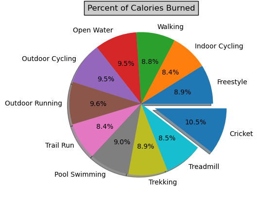

```python
# Data for Workouts

y = np.array([279, 265, 276, 297, 299, 302, 264, 283, 278, 268, 330])
labels = ['Freestyle', 'Indoor Cycling', 'Walking', 'Open Water',
       'Outdoor Cycling', 'Outdoor Running', 'Trail Run', 'Pool Swimming',
       'Trekking', 'Treadmill', 'Cricket']
explode = [0, 0, 0, 0, 0, 0, 0, 0, 0, 0, 0.2]
# Plot
plt.pie(y, labels = labels, explode = explode, shadow = True, autopct='%1.1f%%')
plt.title("Percent of Calories Burned", bbox={'facecolor':'0.8', 'pad':5})
plt.show()
```

```python
# Word Cloud

from wordcloud import WordCloud, STOPWORDS
```

```python
# Create Cloud

final_wordcloud = WordCloud(width = 800, height = 800,
                background_color ='navy',
                stopwords = stop_words,
                min_font_size = 10).generate(comment_words)
```

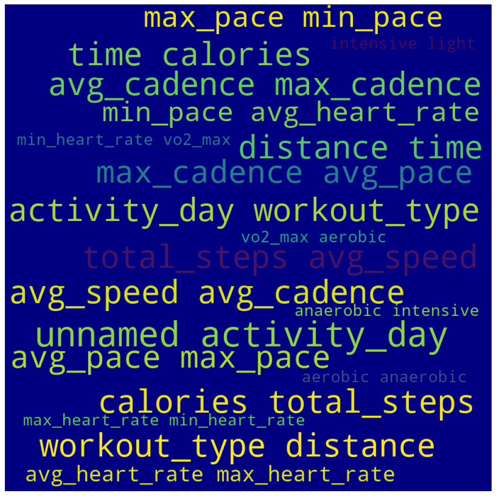

```python
# Print Cloud

plt.figure(figsize = (10, 10), facecolor = None)
plt.imshow(final_wordcloud)
plt.axis("off")
plt.tight_layout(pad = 0)

plt.show()
```